# Lab 4 STA 483

Run ggmonthplot(). Discuss your observations.

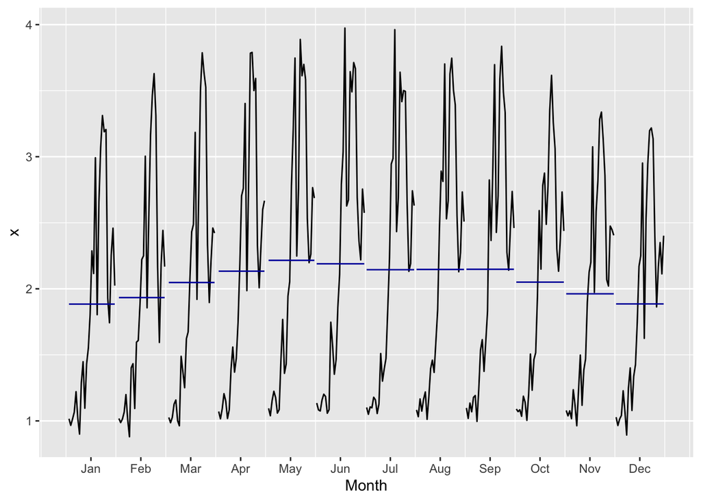

```r
ggmonthplot(reduced.ts)
```

The data shows a slight trend of increase in gas prices throughout the summer, however the increase seems fairly weak. This likely happens as a result of increased travel and demand for gas.

Run ggseasonplot(). Discuss your observations.

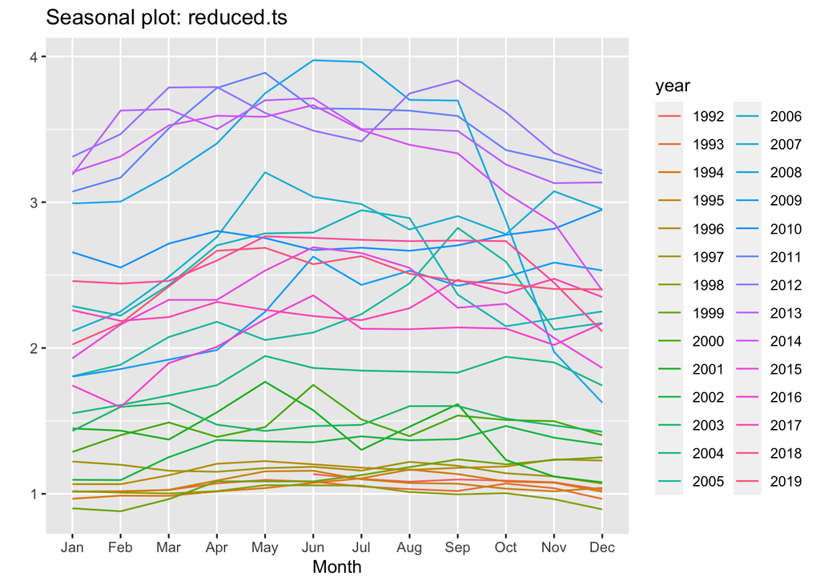

```r
ggseasonplot(reduced.ts)
```

Here we see that there is a slight increase throughout the summer, however this increase is very weak suggesting very slight seasonality. The more glaring change is how prices have changed throughout years, suggestign that exportation of gas has become more costly.

Predict the prices for remainder of the last year. Discuss your findings.

```r
reduced.train <- window(reduced.ts, end=c(2019, 6))
reduced.test <- window(reduced.ts, start=c(2019, 7), end=c(2019, 12))
reduced.test
```

```
##        Jul   Aug   Sep   Oct   Nov   Dec
## 2019 2.630 2.509 2.460 2.438 2.405 2.402
```

```r
reduced.exp <- HoltWinters(reduced.train, beta=FALSE, gamma=FALSE) # Simple Exponential Smoothing
reduced.trend <- HoltWinters(reduced.train, gamma=FALSE)           # Holt Model (Holt Winters, trend only)
reduced.season <- HoltWinters(reduced.train, beta=FALSE)           # forcing trend coefficient to zero
reduced.hw <- HoltWinters(reduced.train)                          # Hold Winters (trend & Season)
```

```r
reduced.for.exp <- forecast(reduced.exp, h=6)
reduced.for.trend <- forecast(reduced.trend, h=length(reduced.test))
reduced.for.season <- forecast(reduced.season, h=length(reduced.test))
reduced.for.hw <- forecast(reduced.hw, h=length(reduced.test))
```

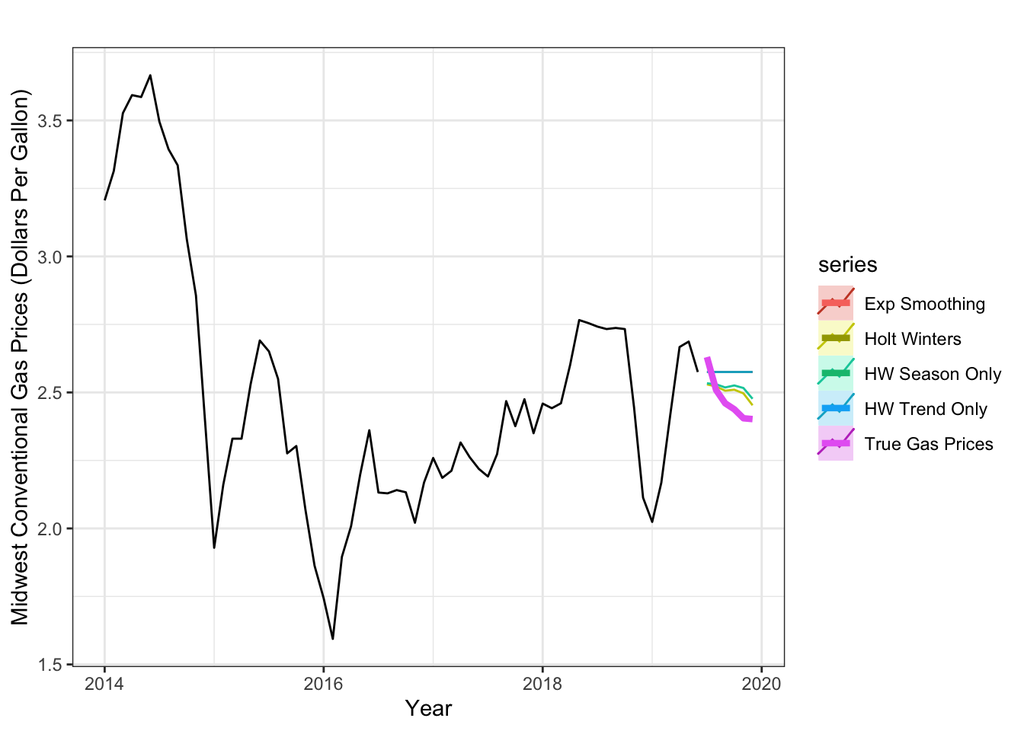

```r
## PI=FALSE says NOT to plot Prediction intervals
autoplot(window(reduced.train, start=c(2014,1))) +
  autolayer(reduced.for.exp, PI=FALSE, series="Exp Smoothing") +
  autolayer(reduced.for.trend, PI=FALSE, series="HW Trend Only") +
  autolayer(reduced.for.hw, PI=FALSE, series="Holt Winters") +
  autolayer(reduced.for.season, PI=FALSE, series="HW Season Only") +
  autolayer(reduced.test, series="True Gas Prices", size=1.5) +
  labs(x="Year", y="Midwest Conventional Gas Prices (Dollars Per Gallon)") +
  theme_bw()
```

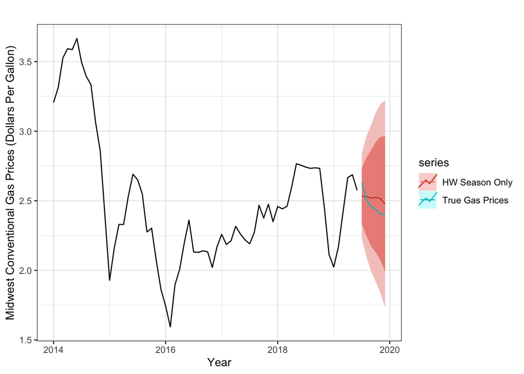

```r
autoplot(window(reduced.train, start=c(2014,1))) +
  autolayer(reduced.for.season, series="HW Season Only") +
  autolayer(reduced.test, series="True Gas Prices") +
  labs(x="Year", y="Midwest Conventional Gas Prices (Dollars Per Gallon)") +
  theme_bw()
```

```r
accuracy(reduced.for.exp, reduced.test)
```

```
##                        ME      RMSE       MAE         MPE     MAPE      MASE
## Training set  0.004444761 0.1566769 0.1038168  0.01083861 4.917278 0.3094611
## Test set     -0.101007404 0.1279407 0.1193383 -4.18436134 4.881352 0.3557281
##                   ACF1 Theil's U
## Training set 0.3331852        NA
## Test set     0.3493702  2.396699
```

```r
accuracy(reduced.for.trend, reduced.test)
```

```
##                        ME      RMSE       MAE        MPE     MAPE      MASE
## Training set  0.009067675 0.1581916 0.1063017  0.5706034 5.093509 0.3168683
## Test set     -0.101143110 0.1280871 0.1194628 -4.1899323 4.886499 0.3560994
##                   ACF1 Theil's U
## Training set 0.3348043        NA
## Test set     0.3495480  2.399584
```

```r
accuracy(reduced.for.season, reduced.test)
```

```
##                       ME       RMSE        MAE         MPE     MAPE      MASE
## Training set  0.00471111 0.15637635 0.10361701  0.04446896 4.874253 0.3088656
## Test set     -0.04271202 0.08038121 0.07486501 -1.81053809 3.033085 0.2231605
##                   ACF1 Theil's U
## Training set 0.3011698        NA
## Test set     0.3114174  1.334098
```

```r
accuracy(reduced.for.hw, reduced.test)
```

```
##                        ME       RMSE        MAE        MPE     MAPE      MASE
## Training set  0.008739768 0.15654920 0.10414595  0.2761864 4.897742 0.3104423
## Test set     -0.028860159 0.06895698 0.06232774 -1.2423256 2.514857 0.1857889
##                   ACF1 Theil's U
## Training set 0.3010837        NA
## Test set     0.2809658  1.055206
```

```r
tab <- rbind(accuracy(reduced.for.exp, reduced.test)[2,2:3],
             accuracy(reduced.for.trend, reduced.test)[2,2:3],
             accuracy(reduced.for.season, reduced.test)[2,2:3],
             accuracy(reduced.for.hw, reduced.test)[2,2:3] )
rownames(tab) <- c("Exp Smoothing", "Holt (trend)", "HW (Season only)", "Holt Winters")
kable(tab)
```

|  | RMSE | MAE |
| --- | --- | --- |
| Exp Smoothing | 0.1279407 | 0.1193383 |
| Holt (trend) | 0.1280871 | 0.1194628 |
| HW (Season only) | 0.0803812 | 0.0748650 |
| Holt Winters | 0.0689570 | 0.0623277 |

From the output above the Holt Winters predicts the data the best, as a result of having the lowest RMSE, and the plot above.

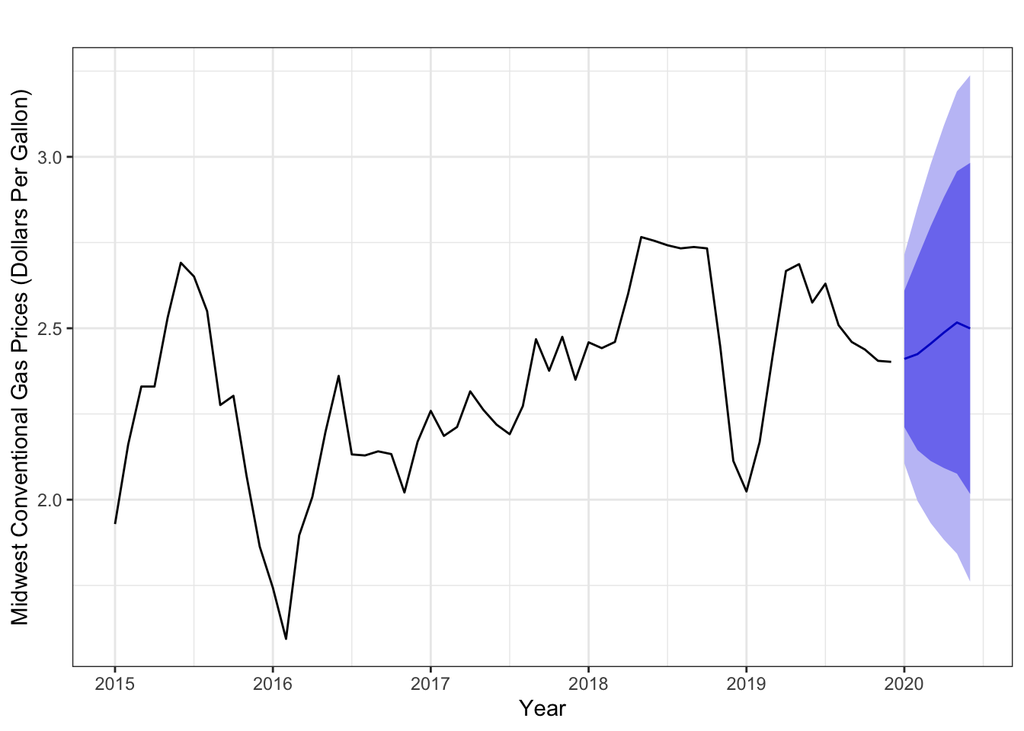

```r
reduced.hw.full <- HoltWinters(reduced.ts, beta=FALSE) # HW Season only
reduced.hw.forecast <- forecast(reduced.hw.full, h=6)
autoplot(window(reduced.ts, start=c(2015,1))) +
  autolayer(reduced.hw.forecast) +
  labs(x="Year", y="Midwest Conventional Gas Prices (Dollars Per Gallon)") +
  theme_bw()
```

```r
reduced.hw.forecast
```

```
##          Point Forecast    Lo 80    Hi 80    Lo 95    Hi 95
## Jan 2020       2.410536 2.211442 2.609631 2.106047 2.715025
## Feb 2020       2.424570 2.144694 2.704447 1.996536 2.852604
## Mar 2020       2.455023 2.112937 2.797109 1.931847 2.978199
## Apr 2020       2.487115 2.092508 2.881723 1.883615 3.090616
## May 2020       2.516806 2.075889 2.957722 1.842482 3.191129
## Jun 2020       2.499522 2.016718 2.982325 1.761137 3.237906
```

Reflect on this LAB. Consider the following questions: What did you learn from this LAB? How closely this LAB was related to the demos presented in class? Has this LAB enhanced your understanding of the TS analysis presented in Module on Trends? What would you change in this LAB to make it easier for students in this course?

From this LAB I learned how to find the best model for predicting a time series. This LAB is very closely related to the demos presented in class, I think the demos do a good job of explaining how the data wrangling should be done and what all the plots mean. This LAB has enhanced my understanding of the TS analysis presented in Module on Trends. I don’t think there is anything that could be changed.